# HSS8005: Quantitative Linguistics - Session 4

Semester 2 2018-19, Danielle Turton

# Today’s data

Today we’ll be working with a dataset coded by my Stage 3 students on SEL3094 *Accents of English* from last year. It is the sociolinguistic variable (ing), so whether speakers say a word like *dancing* with an alveolar [n] or a velar [ŋ]. The data is taken from interviews with Tyneside English speakers, from the DECTE corpus.

Load in our usual packages:

```r
library(dplyr)
library(ggplot2)
```

Let’s load in our data:

```r
ing_data = read.csv("ing.csv")
```

Let’s perform the usual functions:

```r
dim(ing_data)
```

```
[1] 718   7
```

```r
head(ing_data)
```

|  | file | realisation | grammatical_cat | duration | word | fol_seg | vowels_per_second |
| --- | --- | --- | --- | --- | --- | --- | --- |
| 1 | 2012_SEL2091_009_b | in | verb | 0.151 | LIVING | HH | 3.863 |
| 2 | 2012_SEL2091_009_b | in | verb | 0.030 | DOING | W | 6.924 |
| 3 | 2012_SEL2091_009_b | in | noun | 0.239 | MORNING | sp | 3.322 |
| 4 | 2012_SEL2091_009_b | in | verb | 0.099 | DOING | T | 5.294 |
| 5 | 2012_SEL2091_009_b | in | verb | 0.031 | DOING | IH | 6.923 |
| 6 | 2012_SEL2091_009_b | ing | thing | 0.091 | ANYTHING | EH | 5.438 |

```r
tail(ing_data)
```

|  | file | realisation | grammatical_cat | duration | word | fol_seg | vowels_per_second |
| --- | --- | --- | --- | --- | --- | --- | --- |
| 713 | 2012_SEL2091_049_b | in | verb | NA | LOOKING | sp | 7.255 |
| 714 | 2012_SEL2091_049_b | in | verb | NA | SITTING | DH | 12.140 |
| 715 | 2012_SEL2091_049_b | ing | verb | NA | MAKING | ns | 4.494 |
| 716 | 2012_SEL2091_049_b | in | thing | NA | SOMETHING | R | 9.859 |
| 717 | 2012_SEL2091_049_b | in | verb | NA | DOING | DH | 11.704 |
| 718 | 2012_SEL2091_049_b | ing | thing | NA | NOTHING | sp | 0.445 |

```r
colnames(ing_data)
```

```
[1] "file"              "realisation"       "grammatical_cat"   "duration"
[5] "word"              "fol_seg"           "vowels_per_second"
```

Look at the data? Which is our dependent variable? Which factors might be interesting independent variables? Are there any variables that might be useful to have that are not there?

Let’s check out the factor levels of the dependent variable:

```r
levels(ing_data$realisation)
```

```
[1] "in"  "ing"
```

Which is most common?

```r
table(ing_data$realisation)
```

```
 in ing
433 285
```

Let’s make a graph based on grammatical category:

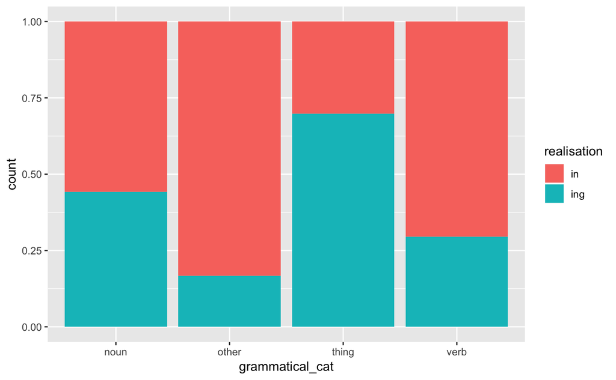

```r
ggplot(ing_data, aes(grammatical_cat, fill = realisation)) + geom_bar(position = "fill")
```

I would like to make a graph of the following sound to see if that has an effect on whether we get the alveolar or velar variant. Let’s make a graph of that:

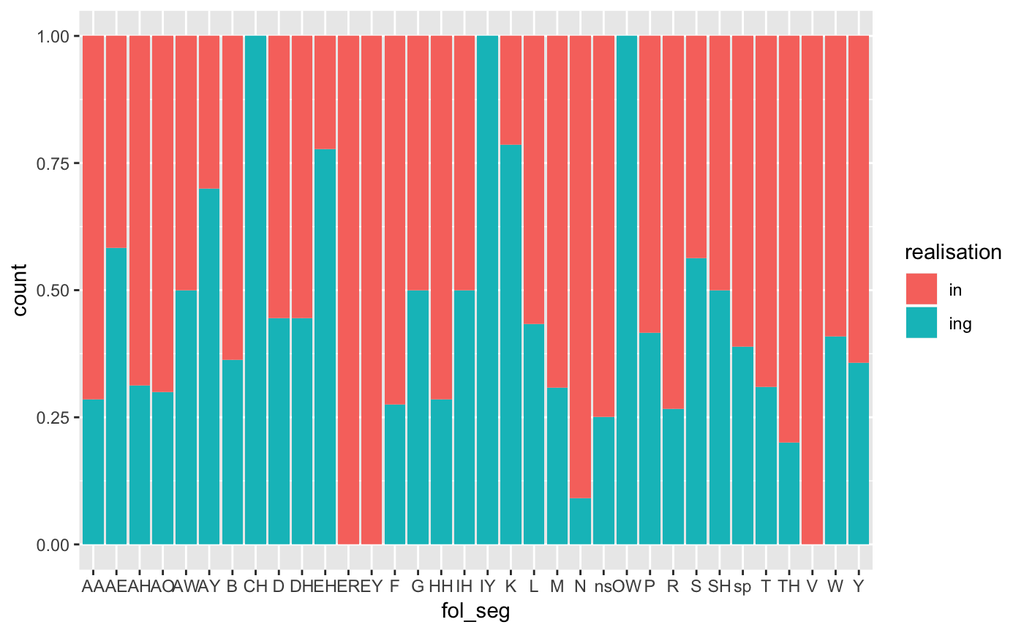

```r
ggplot(ing_data, aes(fol_seg, fill = realisation)) + geom_bar(position = "fill")
```

It’s a bit of a mess. I actually only really want to see if it’s a vowel, consonant or pause following. Note that a following pause in the data is annotated with `sp`, which I think means *space*. The other symbols are from the Arpabet, which is a keyboard alternative to the IPA. You can find out what the codes mean here: (https://en.wikipedia.org/wiki/ARPABET).

How can we make our data a bit more manageable in this sense? We can recode it.

# Tidying data

Let’s make a new column called `fol_context`, where we simplify `fol_seg` into just vowel, consonant and pause. We can do this fairly easily in `dplyr` although the code will be long. Firstly, we need to know what we want to change. Let’s look at the factor levels of `fol_seg`.

```r
levels(ing_data$fol_seg)
```

```
 [1] "AA" "AE" "AH" "AO" "AW" "AY" "B"  "CH" "D"  "DH" "EH" "ER" "EY" "F"  "G"  "HH" "IH" "IY"
[19] "K"  "L"  "M"  "N"  "ns" "OW" "P"  "R"  "S"  "SH" "sp" "T"  "TH" "V"  "W"  "Y"
```

There are 34 levels that we need to recode. This might take a while to type from scratch, but the `dplyr` verb `mutate` is very helpful here…

```r
ing_data = ing_data %>%
  mutate(fol_context = recode(fol_seg,
          "AA" = "vowel", "AE" = "vowel", "AH" = "vowel", "AO" = "vowel",
          "AW" = "vowel", "AY" = "vowel", "B" = "consonant",
          "CH" = "consonant", "D"  = "consonant", "DH" = "consonant",
          "EH"  = "vowel", "ER"  = "vowel", "EY" = "vowel",
          "F"  = "consonant", "G"  = "consonant", "HH"  = "consonant",
          "IH" = "vowel", "IY"  = "vowel", "K"  = "consonant",
          "L"  = "consonant",  "M" = "consonant",  "N"  = "consonant",
          "ns" = "pause", "OW" = "vowel", "P"  = "consonant",
          "R"  = "consonant", "S"  = "consonant", "SH" = "consonant",
          "sp"  = "pause", "T" = "consonant",  "TH" = "consonant",
          "V" = "consonant",  "W" = "consonant",  "Y" = "consonant" ))
```

Can you think of any other ways to recode this?

Let’s try plotting `fol_context` in the chunk below:

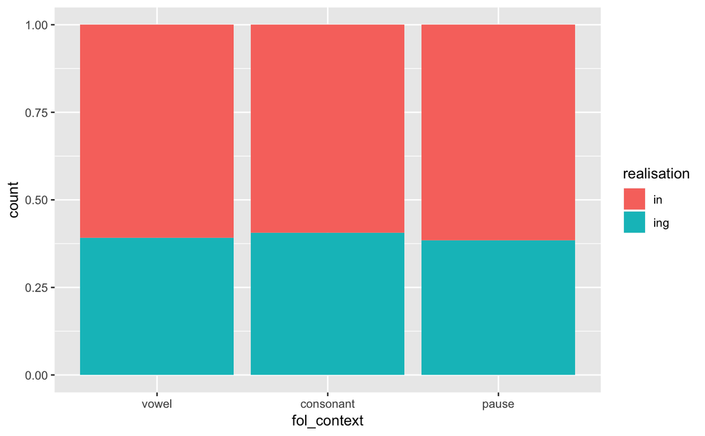

```r
ggplot(ing_data, aes(fol_context, fill = realisation)) + geom_bar(position = "fill")
```

What do we find?

If you have finished this bit and want more of a challenge, try creating another variable based on `fol_seg` which is not as simplified as `fol_context`.

# Joining datasets

It would be good if we knew something about our interviewees - (ing) is a major sociolinguistic variable after all and is conditioned by sex, social class etc. Do we have this data?

Yes, we do, but it’s in another spreadsheet. Take a look at `social.csv` on your computer. Let’s read it in and call it `social`:

```r
social = read.csv("social.csv")
social
```

| file | name | sex | occupation | social_class | age |
| --- | --- | --- | --- | --- | --- |
| 2012_SEL2091_002_a | SamuelR | male | student | MC | 20 |
| 2012_SEL2091_002_b | MikeP | male | student | MC | 20 |
| 2012_SEL2091_009_b | WendyH | female | civil servant | MC | 46 |
| 2012_SEL2091_009_a | FletcherC | male | deputy headmaster | MC | 55 |
| 2012_SEL2091_049_a | BeyonceR | female | student | WC | 19 |
| 2012_SEL2091_049_b | MillicentJ | female | student | WC | 19 |
| 2012_SEL2091_069_a | SueS | female | occupational therapist | WC | 50 |
| 2012_SEL2091_069_b | DavidM | male | prison officer | WC | 53 |
| 2013_SEL2091_054_a | GarethW | male | care worker | WC | 48 |
| 2013_SEL2091_054_b | MadeleineR | female | retired | WC | 70 |

It’s only a small spreadsheet, which includes the codes for the speakers, but also some details about them. It would be good if we could add these relevant columns to our big dataset.

Fortunately, we can do this very easily with a `dplyr` function called `left_join`. This is just one of many joining functions that you can read about [here](http://stat545.com/bit001_dplyr-cheatsheet.html). Specifically, `left_join` will keep all rows from the first dataset listed (or the leftmost one), and then match them up to relevant rows in the second dataset listed (the rightmost one). You can specify which columns should match, but to make it as easy as possible, we already have matching column names in the two datasets we want to join. Let’s look:

```r
colnames(ing_data)
```

```
[1] "file"              "realisation"       "grammatical_cat"   "duration"
[5] "word"              "fol_seg"           "vowels_per_second" "fol_context"
```

```r
colnames(social)
```

```
[1] "file"         "name"         "sex"          "occupation"   "social_class" "age"
```

Both datasets have a factor called `file`, so we should be OK. But first, let’s just check that that have the same factor levels:

```r
levels(ing_data$file)
```

```
 [1] "2012_SEL2091_002_a" "2012_SEL2091_002_b" "2012_SEL2091_009_a" "2012_SEL2091_009_b"
 [5] "2012_SEL2091_049_a" "2012_SEL2091_049_b" "2012_SEL2091_069_a" "2012_SEL2091_069_b"
 [9] "2013_SEL2091_054_a" "2013_SEL2091_054_b"
```

```r
levels(social$file)
```

```
 [1] "2012_SEL2091_002_a" "2012_SEL2091_002_b" "2012_SEL2091_009_a" "2012_SEL2091_009_b"
 [5] "2012_SEL2091_049_a" "2012_SEL2091_049_b" "2012_SEL2091_069_a" "2012_SEL2091_069_b"
 [9] "2013_SEL2091_054_a" "2013_SEL2091_054_b"
```

They both look the same. The way `left_join` works means that it only cares about the first (left) dataset, so if there were factor levels in the second one that were not found in the first, R would just drop them. If it was the other way around, R would just put `NA`s in for the missing social data.

Let’s join!

```r
ing_data = left_join(ing_data, social)
```

Now we have our social information on, try making a plot below of speaker sex against (ing).

## facet wrap

In `ggplot`, we can add what is called a facet wrap, to look at two independent variables at a time. Here’s how we would look at `sex` and `social_class` at the same time:

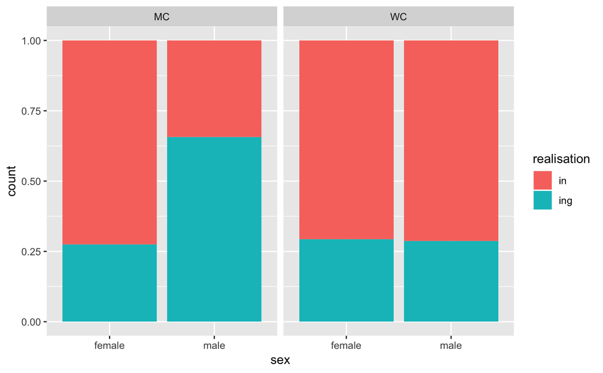

```r
ggplot(ing_data, aes(sex, fill = realisation)) + geom_bar(position="fill") +
  facet_wrap(~social_class)
```

What information does this graph give us that the other doesn’t?

# Basic statistical tests

We can see from our graphs that females use *in* more than males in our dataset. But is this statistically significant?

We can test this with a simple chi-square test. A chi-square test looks at whether the numbers we have in our dataset are significantly different to what we would get if there was no difference between males and females. The chi-square test returns a p-value. If the p-value is less than 0.05, we can conclude that the result is significant.

For now, we can run a chi-square by running the function on our table of **raw counts**, not percentages. Let’s first create such a table:

```r
ing_sex.tbl = table(ing_data$realisation, ing_data$sex)
ing_sex.tbl
```

```
      female male
  in     247  186
  ing    101  184
```

```r
# chi-square test on our table
chisq.test(ing_sex.tbl, correct = FALSE)
```

```
    Pearson's Chi-squared test

data:  ing_sex.tbl
X-squared = 32.122, df = 1, p-value = 1.448e-08
```

What does this mean? Is this statistically significant?

By default, R applies [Yates’s continuity correction](https://en.wikipedia.org/wiki/Yates's_correction_for_continuity) to the test, so the `correct = FALSE` part removes this. Or you can leave this part of the code out to be very strict, but some say this can result in a Type II error.

[figure not shown]

# More plots

I am now going to make a series of potentially useless graphs, to demonstrate `ggplot2`’s capabilities.

### Continuous dependent variable AND independent variable: `geom_point`

Young people speak so fast these days! Let’s prove this with a graph.

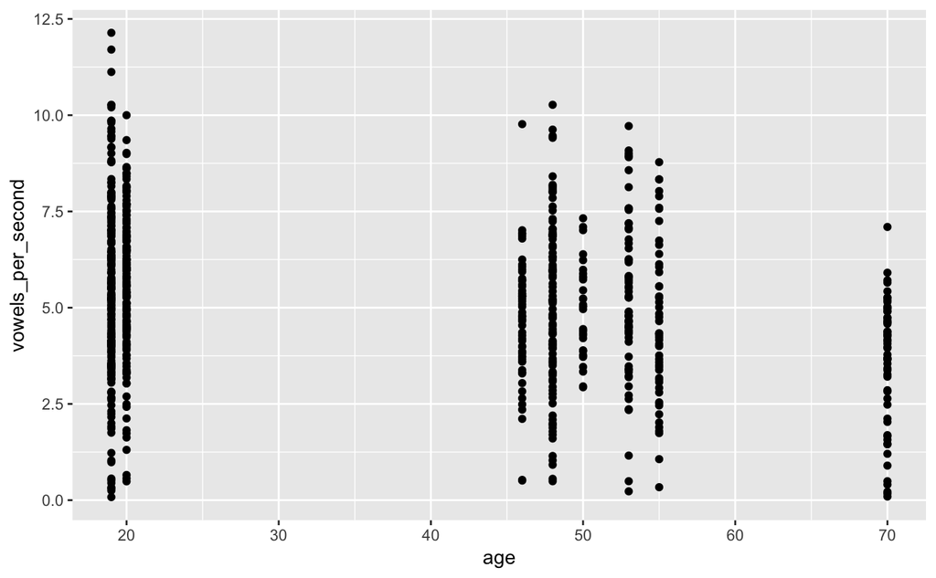

```r
# making a plot of speech rate by age
ggplot(ing_data,  aes(age, vowels_per_second))+
  geom_point()
```

Because we have many points from one speaker of the same age, our graph looks a little weird. Again, this is used as proof of principle. However, we can get it look a bit better than this by adding a smoothing line:

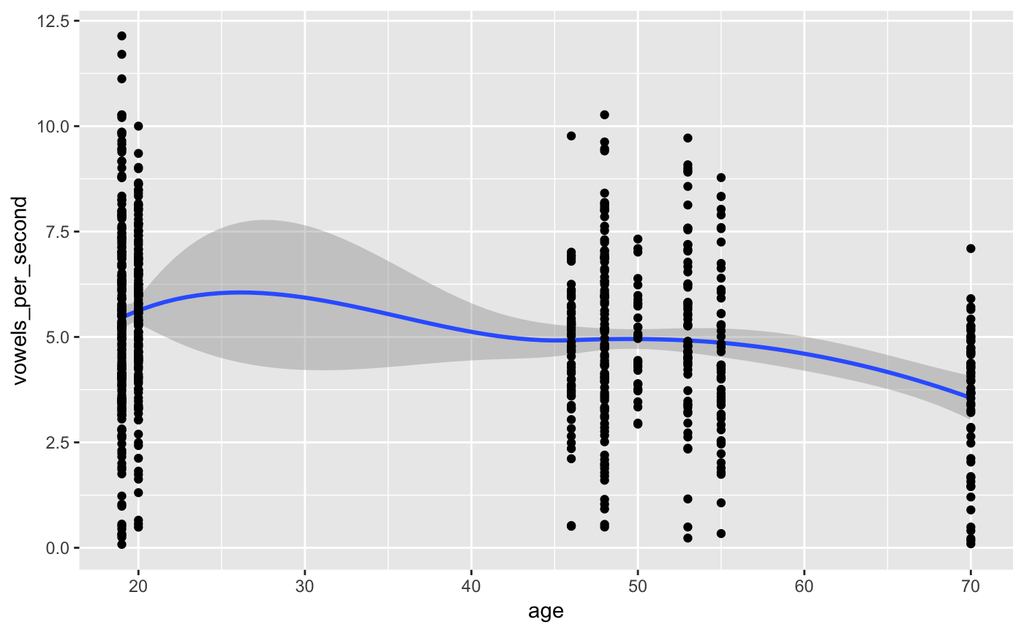

```r
# making a plot of speech rate, smoothing line
ggplot(ing_data,  aes(age, vowels_per_second))+
stat_smooth()+ #smoothing line
geom_point()
```

Or if we want a straight line (based on a linear model), change the code to this:

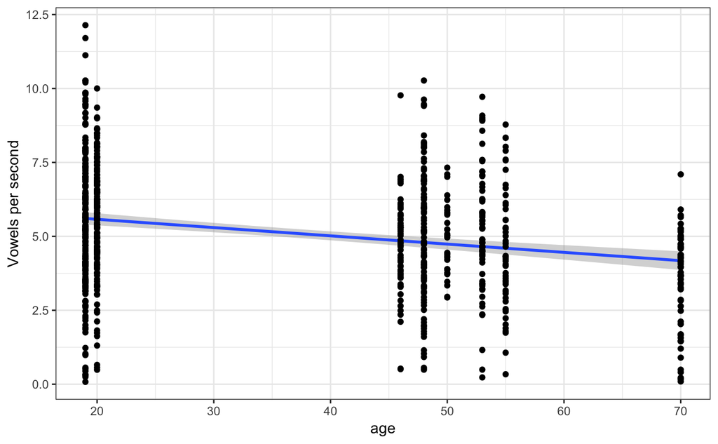

```r
# making a plot of speech rate, straight line
ggplot(ing_data,  aes(age, vowels_per_second))+
  stat_smooth(method="lm")+
  geom_point()+
  ylab("Vowels per second") + #change y axis to this
  theme_bw() + #gets rid of grey background
  theme(legend.position="none")
```

Let’s make it more colourful. Warning, we should change the colours within `geom_point`, because if we try to do it where we normally do it, `ggplot2` will think that this should contribute to the stats of the line (why not try doing that to see what happens?).

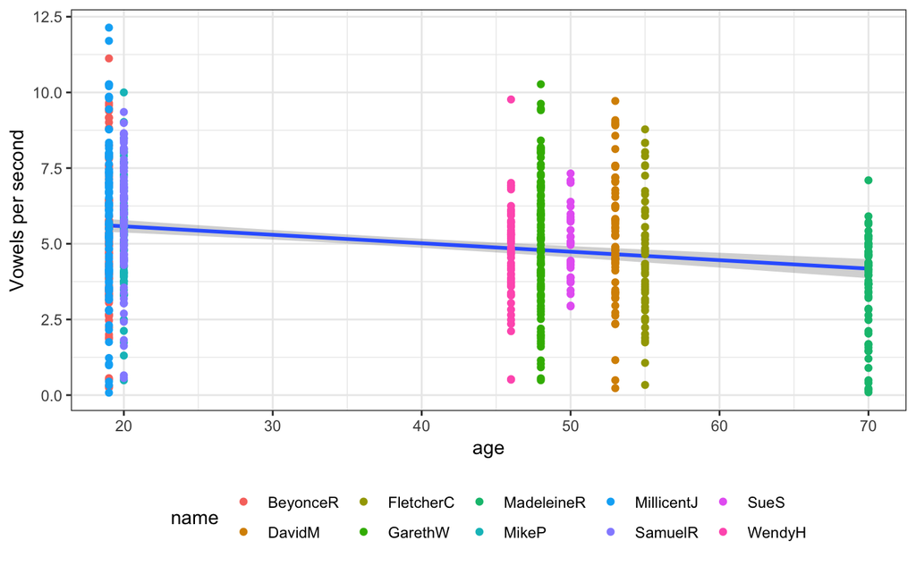

```r
# making a plot of speech rate, straight line, colour
ggplot(ing_data,  aes(age, vowels_per_second))+
  stat_smooth(method="lm")+
  geom_point(aes(colour=name))+
  ylab("Vowels per second") + #change y axis to this
  theme_bw() + #gets rid of grey background
  theme(legend.position="bottom")
```

# Correlations

We can test if vowels per second and speaker age are correlated. Pearson’s Product-Moment Correlation Coefficient is a standardised measure of the relationship between two continuous variables. Correlation does not equal causation. Positive numbers mean the correlation is positive (the higher one goes, the higher the other goes), negative correlations mean the correlation is negative (the higher one goes, the lower the other gets).

Interpretation: ∗ 0–0.2 = very weak ∗ 0.2–0.4 = weak ∗ 0.4 – 0.6 = moderate  
∗ 0.6 – 0.8 = strong ∗ 0.8 – 1 = very strong

Let’s run a correlation in R

```r
head(ing_data)
```

|  | file | realisation | grammatical_cat | duration | word | fol_seg | vowels_per_second | fol_context | name | sex | occupation | social_class | age |
| --- | --- | --- | --- | --- | --- | --- | --- | --- | --- | --- | --- | --- | --- |
| 1 | 2012_SEL2091_009_b | in | verb | 0.151 | LIVING | HH | 3.863 | consonant | WendyH | female | civil servant | MC | 46 |
| 2 | 2012_SEL2091_009_b | in | verb | 0.030 | DOING | W | 6.924 | consonant | WendyH | female | civil servant | MC | 46 |
| 3 | 2012_SEL2091_009_b | in | noun | 0.239 | MORNING | sp | 3.322 | pause | WendyH | female | civil servant | MC | 46 |
| 4 | 2012_SEL2091_009_b | in | verb | 0.099 | DOING | T | 5.294 | consonant | WendyH | female | civil servant | MC | 46 |
| 5 | 2012_SEL2091_009_b | in | verb | 0.031 | DOING | IH | 6.923 | vowel | WendyH | female | civil servant | MC | 46 |
| 6 | 2012_SEL2091_009_b | ing | thing | 0.091 | ANYTHING | EH | 5.438 | vowel | WendyH | female | civil servant | MC | 46 |

```r
cor(ing_data$vowels_per_second, ing_data$age)
```

```
[1] -0.2372971
```

What does this mean?

# Linear models

Let’s test on the `ChickWeight` dataset.

```r
head(ChickWeight)
```

|  | weight | Time | Chick | Diet |
| --- | --- | --- | --- | --- |
| 1 | 42 | 0 | 1 | 1 |
| 2 | 51 | 2 | 1 | 1 |
| 3 | 59 | 4 | 1 | 1 |
| 4 | 64 | 6 | 1 | 1 |
| 5 | 76 | 8 | 1 | 1 |
| 6 | 93 | 10 | 1 | 1 |

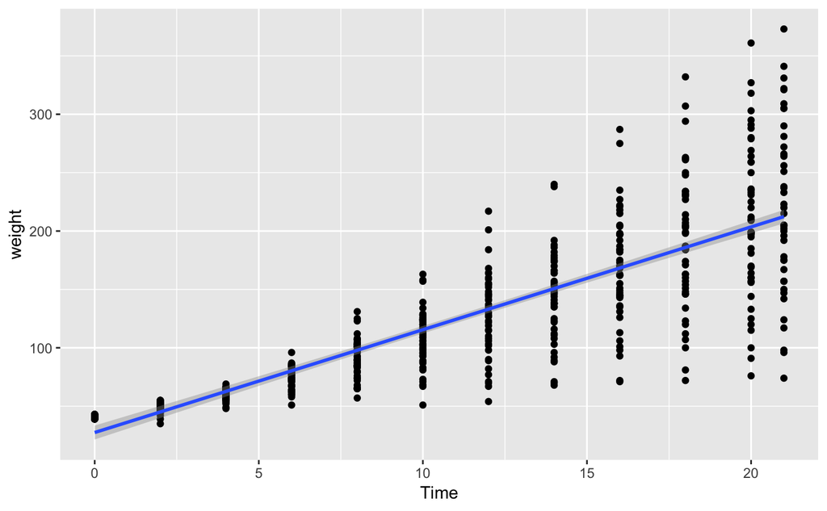

```r
ggplot(ChickWeight, aes(Time, weight)) + geom_point() + stat_smooth(method="lm")
```

Linear model:

```r
mod = lm(weight ~ Time, data = ChickWeight)
summary(mod)
```

```
Call:
lm(formula = weight ~ Time, data = ChickWeight)

Residuals:
     Min       1Q   Median       3Q      Max
-138.331  -14.536    0.926   13.533  160.669

Coefficients:
            Estimate Std. Error t value Pr(>|t|)
(Intercept)  27.4674     3.0365   9.046   <2e-16 ***
Time          8.8030     0.2397  36.725   <2e-16 ***
---
Signif. codes:  0 ‘***’ 0.001 ‘**’ 0.01 ‘*’ 0.05 ‘.’ 0.1 ‘ ’ 1

Residual standard error: 38.91 on 576 degrees of freedom
Multiple R-squared:  0.7007,    Adjusted R-squared:  0.7002
F-statistic:  1349 on 1 and 576 DF,  p-value: < 2.2e-16
```

Do you understand the most important parts of the model?

Let’s try for vowels per second and age:

```r
mod_vps = lm(vowels_per_second ~ age, data = ing_data)
summary(mod_vps)
```

```
Call:
lm(formula = vowels_per_second ~ age, data = ing_data)

Residuals:
    Min      1Q  Median      3Q     Max
-5.5246 -1.2932 -0.0109  1.2457  6.5354

Coefficients:
             Estimate Std. Error t value Pr(>|t|)
(Intercept)  6.135766   0.174880  35.086  < 2e-16 ***
age         -0.027958   0.004277  -6.536  1.2e-10 ***
---
Signif. codes:  0 ‘***’ 0.001 ‘**’ 0.01 ‘*’ 0.05 ‘.’ 0.1 ‘ ’ 1

Residual standard error: 2.04 on 716 degrees of freedom
Multiple R-squared:  0.05631,   Adjusted R-squared:  0.05499
F-statistic: 42.72 on 1 and 716 DF,  p-value: 1.198e-10
```

## Generalised linear models

For categorical variables. The assumptions are different (see slides) which is why we need to add the `family = binomial` call.

Let’s try for (ing) realisation vs. age.

```r
mod_ing_age = glm(realisation ~ age, data = ing_data, family = "binomial")
summary(mod_ing_age)
```

```
Call:
glm(formula = realisation ~ age, family = "binomial", data = ing_data)

Deviance Residuals:
    Min       1Q   Median       3Q      Max
-1.0534  -1.0507  -0.9622   1.3097   1.4607

Coefficients:
             Estimate Std. Error z value Pr(>|z|)
(Intercept) -0.169876   0.174387  -0.974    0.330
age         -0.006790   0.004313  -1.574    0.115

(Dispersion parameter for binomial family taken to be 1)

    Null deviance: 964.63  on 717  degrees of freedom
Residual deviance: 962.14  on 716  degrees of freedom
AIC: 966.14

Number of Fisher Scoring iterations: 4
```

What do the estimates mean here? Less clear, but a 0 is assigned to `in`, the first factor level, and a 1 is assigned to `ing`, the second factor level. Therefore, a positive estimate means more `ing` and a negative more `in`. This will be specific to your dataset, so you will need to change what comes first.

## Categorical predictors

Let’s try for vowels per second and class:

```r
mod_vps_class = lm(vowels_per_second ~ social_class, data = ing_data)
summary(mod_vps_class)
```

```
Call:
lm(formula = vowels_per_second ~ social_class, data = ing_data)

Residuals:
    Min      1Q  Median      3Q     Max
-4.9764 -1.3414 -0.0259  1.3096  7.0836

Coefficients:
               Estimate Std. Error t value Pr(>|t|)
(Intercept)      5.1894     0.1273  40.766   <2e-16 ***
social_classWC  -0.1330     0.1615  -0.823    0.411
---
Signif. codes:  0 ‘***’ 0.001 ‘**’ 0.01 ‘*’ 0.05 ‘.’ 0.1 ‘ ’ 1

Residual standard error: 2.099 on 716 degrees of freedom
Multiple R-squared:  0.0009459, Adjusted R-squared:  -0.0004494
F-statistic: 0.6779 on 1 and 716 DF,  p-value: 0.4106
```

As you get more advanced, you can try more factors in the model.

```r
mod_social = lm(vowels_per_second ~ social_class + age + sex, data = ing_data)
summary(mod_social)
```

```
Call:
lm(formula = vowels_per_second ~ social_class + age + sex, data = ing_data)

Residuals:
    Min      1Q  Median      3Q     Max
-5.4035 -1.2804  0.0102  1.2745  6.6565

Coefficients:
                Estimate Std. Error t value Pr(>|t|)
(Intercept)     5.805760   0.216196  26.854  < 2e-16 ***
social_classWC  0.252672   0.174586   1.447  0.14826
age            -0.030257   0.004373  -6.919 1.01e-11 ***
sexmale         0.500085   0.167851   2.979  0.00299 **
---
Signif. codes:  0 ‘***’ 0.001 ‘**’ 0.01 ‘*’ 0.05 ‘.’ 0.1 ‘ ’ 1

Residual standard error: 2.031 on 714 degrees of freedom
Multiple R-squared:  0.06795,   Adjusted R-squared:  0.06404
F-statistic: 17.35 on 3 and 714 DF,  p-value: 6.958e-11
```

It doesn’t seem like `social_class` is doing anything. We can compare a model with it in, and a model without it.

Model without social class:

```r
mod_nosocial = lm(vowels_per_second ~ age + sex, data = ing_data)
```

Anova comparison:

```r
anova(mod_social, mod_nosocial)
```

```
Analysis of Variance Table

Model 1: vowels_per_second ~ social_class + age + sex
Model 2: vowels_per_second ~ age + sex
  Res.Df    RSS Df Sum of Sq      F Pr(>F)
1    714 2944.1
2    715 2952.8 -1   -8.6368 2.0946 0.1483
```

If the p-value is non-significant, it means that adding social class into the model does not significantly improve it.

# For future: mixed effects regression

For those of you who want to carry on with more advanced regression, here is how I would do mixed effects linear and logistic regression in R. This is not expected or required for this course.

```r
library(lme4) # needed for mixed effects regression (remember to install first time)
```

linear mixed effects

```r
mod_lmer = lmer(vowels_per_second ~ social_class + age + sex + fol_context + grammatical_cat + (1|word) + (1|name), data = ing_data)
summary(mod_lmer)
```

```
Linear mixed model fit by REML ['lmerMod']
Formula: vowels_per_second ~ social_class + age + sex + fol_context +
    grammatical_cat + (1 | word) + (1 | name)
   Data: ing_data

REML criterion at convergence: 2987.2

Scaled residuals:
    Min      1Q  Median      3Q     Max
-3.1806 -0.6115  0.0125  0.5972  2.9995

Random effects:
 Groups   Name        Variance Std.Dev.
 word     (Intercept) 0.32005  0.5657
 name     (Intercept) 0.02718  0.1649
 Residual             3.48203  1.8660
Number of obs: 718, groups:  word, 156; name, 10

Fixed effects:
                      Estimate Std. Error t value
(Intercept)           6.033704   0.389662  15.484
social_classWC        0.358453   0.205681   1.743
age                  -0.031077   0.005155  -6.028
sexmale               0.433613   0.198277   2.187
fol_contextconsonant -0.245113   0.171401  -1.430
fol_contextpause     -1.471916   0.202964  -7.252
grammatical_catother -0.233200   0.497023  -0.469
grammatical_catthing  0.415753   0.390328   1.065
grammatical_catverb   0.041430   0.279383   0.148

Correlation of Fixed Effects:
              (Intr) scl_WC age    sexmal fl_cntxtc fl_cntxtp grmmtcl_ctthr grmmtcl_ctthn
socl_clssWC   -0.282
age           -0.441 -0.219
sexmale       -0.369  0.400 -0.115
fl_cntxtcns   -0.320  0.046  0.019  0.008
fol_cntxtps   -0.293 -0.017  0.038  0.044  0.519
grmmtcl_ctthr -0.319 -0.045 -0.007  0.006 -0.026    -0.065
grmmtcl_ctthn -0.447 -0.042  0.022  0.076  0.017     0.010     0.328
grmmtcl_ctv   -0.635 -0.060  0.039  0.039  0.051     0.074     0.469         0.572
```

generalised linear mixed effects

```r
mod_glmer = glmer(realisation ~ social_class + age + sex + fol_context + grammatical_cat + (1|word) + (1|name), data = ing_data, family = "binomial")
```

```
Model failed to converge with max|grad| = 0.00155051 (tol = 0.001, component 1)
```

```r
summary(mod_glmer)
```

```
Generalized linear mixed model fit by maximum likelihood (Laplace Approximation) ['glmerMod']
 Family: binomial  ( logit )
Formula: realisation ~ social_class + age + sex + fol_context + grammatical_cat +
    (1 | word) + (1 | name)
   Data: ing_data

     AIC      BIC   logLik deviance df.resid
   722.9    773.2   -350.5    700.9      707

Scaled residuals:
    Min      1Q  Median      3Q     Max
-5.7179 -0.5054 -0.3029  0.4984  6.2273

Random effects:
 Groups Name        Variance Std.Dev.
 word   (Intercept) 0.9276   0.9631
 name   (Intercept) 0.8182   0.9046
Number of obs: 718, groups:  word, 156; name, 10

Fixed effects:
                       Estimate Std. Error z value Pr(>|z|)
(Intercept)          -0.2633499  0.9947950  -0.265 0.791219
social_classWC       -1.4129762  0.7012610  -2.015 0.043914 *
age                  -0.0001862  0.0175101  -0.011 0.991515
sexmale               0.9946757  0.6704227   1.484 0.137901
fol_contextconsonant -0.1135672  0.2437933  -0.466 0.641334
fol_contextpause     -0.0880233  0.2883645  -0.305 0.760176
grammatical_catother -1.3344376  0.7990312  -1.670 0.094906 .
grammatical_catthing  2.2186340  0.5854754   3.789 0.000151 ***
grammatical_catverb  -0.5229298  0.3911498  -1.337 0.181254
---
Signif. codes:  0 ‘***’ 0.001 ‘**’ 0.01 ‘*’ 0.05 ‘.’ 0.1 ‘ ’ 1

Correlation of Fixed Effects:
              (Intr) scl_WC age    sexmal fl_cntxtc fl_cntxtp grmmtcl_ctthr grmmtcl_ctthn
socl_clssWC   -0.397
age           -0.598 -0.216
sexmale       -0.477  0.398 -0.059
fl_cntxtcns   -0.170  0.021  0.006  0.003
fol_cntxtps   -0.162 -0.014  0.021  0.018  0.516
grmmtcl_ctthr -0.154  0.009 -0.003 -0.001 -0.027    -0.042
grmmtcl_ctthn -0.215 -0.026  0.009  0.046 -0.001     0.009     0.238
grmmtcl_ctv   -0.335 -0.010  0.015  0.009  0.039     0.067     0.397         0.483
convergence code: 0
Model failed to converge with max|grad| = 0.00155051 (tol = 0.001, component 1)
```

We get a warning that it has failed to converge. Do not trust models that fail to converge! This is a common problem with glmers (I’m happy to discuss this with you further).